# R Notebook

Read the WHO.csv file into variable who. head(who) gives the first six rows in the csv file

```r
who <- read.csv("C:/DataAnalysis/WHO.csv")
head(who)
```

|  | Country | Region | Population | Under15 | Over60 | FertilityRate | LifeExpectancy | ChildMortality | CellularSubscribers | LiteracyRate | GNI | PrimarySchoolEnrollmentMale | PrimarySchoolEnrollmentFemale |
| --- | --- | --- | --- | --- | --- | --- | --- | --- | --- | --- | --- | --- | --- |
| 1 | Afghanistan | Eastern Mediterranean | 29825 | 47.42 | 3.82 | 5.40 | 60 | 98.5 | 54.26 | NA | 1140 | NA | NA |
| 2 | Albania | Europe | 3162 | 21.33 | 14.93 | 1.75 | 74 | 16.7 | 96.39 | NA | 8820 | NA | NA |
| 3 | Algeria | Africa | 38482 | 27.42 | 7.17 | 2.83 | 73 | 20.0 | 98.99 | NA | 8310 | 98.2 | 96.4 |
| 4 | Andorra | Europe | 78 | 15.20 | 22.86 | NA | 82 | 3.2 | 75.49 | NA | NA | 78.4 | 79.4 |
| 5 | Angola | Africa | 20821 | 47.58 | 3.84 | 6.10 | 51 | 163.5 | 48.38 | 70.1 | 5230 | 93.1 | 78.2 |
| 6 | Antigua and Barbuda | Americas | 89 | 25.96 | 12.35 | 2.12 | 75 | 9.9 | 196.41 | 99.0 | 17900 | 91.1 | 84.5 |

get the summary of the percentage of population under15

```r
summary(who$Under15)
```

```
   Min. 1st Qu.  Median    Mean 3rd Qu.    Max.
  13.12   18.72   28.65   28.73   37.75   49.99
```

Let us analyze which country has got min percentage of population. For this we will be using the which command that returns the row number of the observation with min population under15

```r
which.min(who$Under15)
```

```
[1] 86
```

to see which country is in row 86 japan is the country with min population under15

```r
who$Country[86]
```

```
[1] Japan
194 Levels: Afghanistan Albania Algeria Andorra ... Zimbabwe
```

Let us analyze which country has got max percentage of population use which command that returns the row number of the observation with max population under15.

```r
which.max(who$Under15)
```

```
[1] 124
```

to see which country is in row 124 niger is the country with max population under15

```r
who$Country[124]
```

```
[1] Niger
194 Levels: Afghanistan Albania Algeria Andorra ... Zimbabwe
```

plot between GNI vs FertilityRate

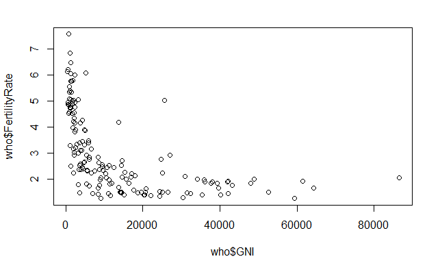

```r
plot(who$GNI,who$FertilityRate)
```

create a subset with conditions where GNI > 10000 and FertilityRate > 2.5

```r
outliers = subset(who, GNI > 10000 & FertilityRate >2.5)
nrow(outliers)
```

```
[1] 7
```

To view the rows in subset outliers

```r
outliers[c("Country","GNI","FertilityRate")]
```

|  | Country | GNI | FertilityRate |
| --- | --- | --- | --- |
| 23 | Botswana | 14550 | 2.71 |
| 56 | Equatorial Guinea | 25620 | 5.04 |
| 63 | Gabon | 13740 | 4.18 |
| 83 | Israel | 27110 | 2.92 |
| 88 | Kazakhstan | 11250 | 2.52 |
| 131 | Panama | 14510 | 2.52 |
| 150 | Saudi Arabia | 24700 | 2.76 |

What is the mean value of the “Over60” variable?

```r
mean(who$Over60)
```

```
[1] 11.16366
```

Which country has the smallest percentage of the population over 60? Which country has the largest literacy rate?

```r
which.min(who$Over60)
```

```
[1] 183
```

```r
who$Country[183]
```

```
[1] United Arab Emirates
194 Levels: Afghanistan Albania Algeria Andorra ... Zimbabwe
```

Which country has the largest literacy rate?

```r
summary(who$LiteracyRate)
```

```
   Min. 1st Qu.  Median    Mean 3rd Qu.    Max.    NA's
  31.10   71.60   91.80   83.71   97.85   99.80      91
```

```r
which.max(who$LiteracyRate)
```

```
[1] 44
```

```r
who$Country[44]
```

```
[1] Cuba
194 Levels: Afghanistan Albania Algeria Andorra ... Zimbabwe
```

tapply is a command used to compute mathematical calculations like min,max,avg,mean. tapply is used when there are two variables, one numerical variable and one categorical variable.

```r
tapply(who$Over60,who$Region,mean)
```

```
               Africa              Americas Eastern Mediterranean
             5.220652             10.943714              5.620000
               Europe       South-East Asia       Western Pacific
            19.774906              8.769091             10.162963
```

```r
tapply(who$LiteracyRate, who$Region,min)
```

```
               Africa              Americas Eastern Mediterranean
                   NA                    NA                    NA
               Europe       South-East Asia       Western Pacific
                   NA                    NA                    NA
```

Here, we have got NA values that means some of the values are missing. To remove NA values

```r
tapply(who$LiteracyRate, who$Region,min, na.rm = TRUE)
```

```
               Africa              Americas Eastern Mediterranean
                 31.1                  75.2                  63.9
               Europe       South-East Asia       Western Pacific
                 95.2                  56.8                  60.6
```

```r
tapply(who$ChildMortality, who$Region,min)
```

```
               Africa              Americas Eastern Mediterranean
                 13.1                   5.3                   7.4
               Europe       South-East Asia       Western Pacific
                  2.2                   9.6                   2.9
```